# Technical Appendix

Antonio Skilton

## The Data

#### The election data

The data I am using is from US Election Atlas, which sells proprietary data. As a result, I will not include their entire dataset here. Instead, I will only include a variable that represents the vote difference between the candidates on a county level.

```r
library(tidyverse)
```

```r
election <- read_csv("data/clean/Pres_Election_Data_2016i.csv", col_types = cols())
```

“Margin” represents the margin of victory with which Donald Trump won a particular county. A positive value corresponds to a Trump victory, a negative value corresponds to a Clinton victory.

| STATEFIPS | COUNTY | vote_difference | victor |
| --- | --- | --- | --- |
| 1 | 3 | 0.5721 | Trump |
| 1 | 5 | 0.0560 | Trump |
| 1 | 7 | 0.5513 | Trump |
| 1 | 9 | 0.8092 | Trump |
| 1 | 11 | -0.5077 | Clinton |
| 1 | 13 | 0.1349 | Trump |
| 1 | 15 | 0.4105 | Trump |
| 1 | 17 | 0.1474 | Trump |
| 1 | 19 | 0.6899 | Trump |
| 1 | 21 | 0.6626 | Trump |

[output cut: 990 more lines]

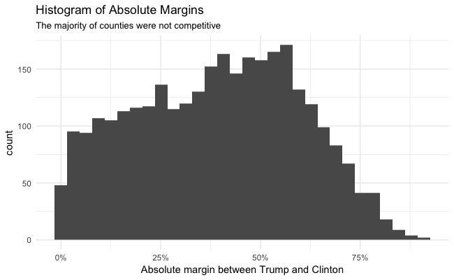

```r
ggplot(election, aes(x = abs(vote_difference))) +
  geom_histogram() +
  scale_x_continuous(labels = scales::percent) +
  labs(title = "Histogram of Absolute Margins",
       subtitle = "The majority of counties were not competitive",
       x = "Absolute margin between Trump and Clinton") +
  theme_minimal()
```

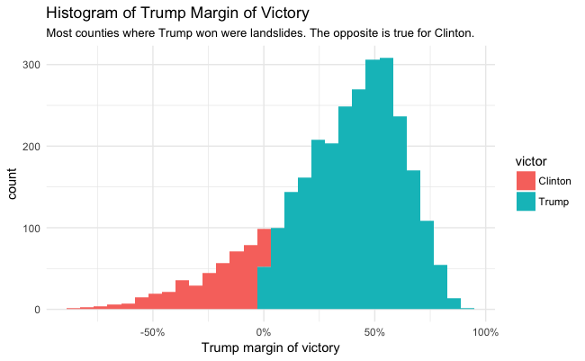

```r
ggplot(election, aes(x = vote_difference, fill = victor)) +
  geom_histogram() +
  scale_x_continuous(labels = scales::percent) +
  labs(title = "Histogram of Trump Margin of Victory",
       subtitle = "Most counties where Trump won were landslides. The opposite is true for Clinton.",
       x = "Trump margin of victory") +
  theme_minimal()
```

#### Other county level data

County Density:

```r
density <- read_csv("data/raw/county_density.csv", skip = 1,
         col_types = cols_only(`Target Geo Id` = col_character(),
                               `Density per square mile of land area - Population` = col_double())) %>%
  filter(nchar(`Target Geo Id`) == 14) %>%
  transmute(STATEFIPS = as.numeric(substr(`Target Geo Id`, start = 10, stop = 11)),
            COUNTY = as.numeric(substr(`Target Geo Id`, start = 12, stop = 14)),
            people_per_sq_mile = `Density per square mile of land area - Population`)
```

| STATEFIPS | COUNTY | People per square mile |
| --- | --- | --- |
| 1 | 1 | 91.8 |
| 1 | 3 | 114.6 |
| 1 | 5 | 31.0 |
| 1 | 7 | 36.8 |
| 1 | 9 | 88.9 |
| 1 | 11 | 17.5 |
| 1 | 13 | 27.0 |
| 1 | 15 | 195.7 |
| 1 | 17 | 57.4 |
| 1 | 19 | 46.9 |

[output cut: 990 more lines]

Affordable Care Act change in uninsured rates [from Enroll America](https://www.enrollamerica.org/research-maps/maps/changes-in-uninsured-rates-by-county/):

```r
insurance <- read_csv("data/raw/County_Data_2016_health_insurance.csv",
         col_types = list(county_fips = col_character())) %>%
  setNames(gsub(pattern = " ", replacement = "_", names(.))) %>%
  transmute(STATEFIPS = ifelse(nchar(county_fips) == 5,
                               as.numeric(substr(county_fips, start = 1, stop = 2)),
                               as.numeric(substr(county_fips, start = 1, stop = 1))),
                               COUNTY = as.numeric(substr(county_fips, start = nchar(county_fips) - 2, stop = nchar(county_fips))),
                               uninsured_rate_2013 = `2013_uninsured_rate` / 100,
                               uninsured_rate_2016 = `2016_uninsured_rate` / 100,
                               decrease_from_2013_to_2016 = decrease_from_2013_to_2016 / 100) %>%
  rename(change = decrease_from_2013_to_2016) %>%
  arrange(STATEFIPS, COUNTY)
```

| STATEFIPS | COUNTY | Rate Uninsured in 2013 | Rate Uninsured in 2016 | change |
| --- | --- | --- | --- | --- |
| 1 | 1 | 0.17 | 0.08 | -0.09 |
| 1 | 3 | 0.17 | 0.08 | -0.09 |
| 1 | 5 | 0.24 | 0.15 | -0.09 |
| 1 | 7 | 0.20 | 0.10 | -0.10 |
| 1 | 9 | 0.19 | 0.10 | -0.09 |
| 1 | 11 | 0.28 | 0.17 | -0.11 |
| 1 | 13 | 0.24 | 0.14 | -0.10 |
| 1 | 15 | 0.21 | 0.11 | -0.10 |
| 1 | 17 | 0.25 | 0.13 | -0.12 |
| 1 | 19 | 0.22 | 0.10 | -0.12 |

[output cut: 990 more lines]

Economic data from the [USDA](https://www.ers.usda.gov/topics/rural-economy-population/rural-classifications.aspx).

```r
econ <- read_csv("data/raw/Unemployment.csv", skip = 6,
         col_types = cols_only(FIPS_Code = col_character(),
                               Unemployment_rate_2015 = col_double(),
                               Median_Household_Income_2014 = col_number())) %>%
  transmute(STATEFIPS = as.numeric(substr(FIPS_Code, 1, 2)),
            COUNTY = as.numeric(substr(FIPS_Code, 3, 5)),
            Unemployment_rate_2015 = Unemployment_rate_2015 / 100,
            Median_Household_Income_2014) %>%
  filter(COUNTY != 0)
```

| STATEFIPS | COUNTY | Unemployment rate in 2015 | Median household income in 2014 |
| --- | --- | --- | --- |
| 1 | 1 | 0.052 | 54366 |
| 1 | 3 | 0.055 | 49626 |
| 1 | 5 | 0.089 | 34971 |
| 1 | 7 | 0.066 | 39546 |
| 1 | 9 | 0.054 | 45567 |
| 1 | 11 | 0.078 | 26580 |
| 1 | 13 | 0.075 | 32512 |
| 1 | 15 | 0.070 | 41123 |
| 1 | 17 | 0.060 | 34116 |
| 1 | 19 | 0.054 | 38013 |

[output cut: 990 more lines]

County characteristics dataset from the [Census](https://www.census.gov/popest/data/counties/asrh/2015/CC-EST2015-ALLDATA.html):

```r
NHWA <- read_csv("data/raw/CC-EST2015-ALLDATA.csv",
         col_types = cols_only(STATE = col_integer(),
                               COUNTY = col_integer(),
                               TOT_POP = col_integer(),
                               AGEGRP = col_integer(),
                               YEAR = col_integer(),
                               NHWA_MALE = col_integer(),
                               NHWA_FEMALE = col_integer()),
         progress = F) %>%
  filter(AGEGRP >= 5,
         YEAR == 8) %>%
  rename(STATEFIPS = STATE) %>%
  group_by(STATEFIPS, COUNTY) %>%
  summarise(TOT_POP = sum(TOT_POP),
            NHWA = sum(NHWA_MALE + NHWA_FEMALE) / sum(TOT_POP))
```

| STATEFIPS | COUNTY | Total Population (TOT_POP) | Non-Hispanic White Alone (NHWA) |
| --- | --- | --- | --- |
| 1 | 1 | 40372 | 0.76617458 |
| 1 | 3 | 154649 | 0.85194861 |
| 1 | 5 | 20379 | 0.49482310 |
| 1 | 7 | 17438 | 0.73959170 |
| 1 | 9 | 43050 | 0.90041812 |
| 1 | 11 | 8254 | 0.24339714 |
| 1 | 13 | 14962 | 0.55647641 |
| 1 | 15 | 87046 | 0.75316499 |
| 1 | 17 | 26147 | 0.58683597 |
| 1 | 19 | 20156 | 0.92587815 |

[output cut: 990 more lines]

I join these datasets:

```r
joined_data <- election %>%
  inner_join(density) %>%
  inner_join(insurance) %>%
  inner_join(econ) %>%
  inner_join(NHWA)
```

| STATEFIPS | COUNTY | vote_difference | victor | people_per_sq_mile | uninsured_rate_2013 | uninsured_rate_2016 | change | Unemployment_rate_2015 | Median_Household_Income_2014 | TOT_POP | NHWA |
| --- | --- | --- | --- | --- | --- | --- | --- | --- | --- | --- | --- |
| 1 | 3 | 0.5721 | Trump | 114.6 | 0.17 | 0.08 | -0.09 | 0.055 | 49626 | 154649 | 0.8519486 |
| 1 | 5 | 0.0560 | Trump | 31.0 | 0.24 | 0.15 | -0.09 | 0.089 | 34971 | 20379 | 0.4948231 |
| 1 | 7 | 0.5513 | Trump | 36.8 | 0.20 | 0.10 | -0.10 | 0.066 | 39546 | 17438 | 0.7395917 |
| 1 | 9 | 0.8092 | Trump | 88.9 | 0.19 | 0.10 | -0.09 | 0.054 | 45567 | 43050 | 0.9004181 |
| 1 | 11 | -0.5077 | Clinton | 17.5 | 0.28 | 0.17 | -0.11 | 0.078 | 26580 | 8254 | 0.2433971 |
| 1 | 13 | 0.1349 | Trump | 27.0 | 0.24 | 0.14 | -0.10 | 0.075 | 32512 | 14962 | 0.5564764 |
| 1 | 15 | 0.4105 | Trump | 195.7 | 0.21 | 0.11 | -0.10 | 0.070 | 41123 | 87046 | 0.7531650 |
| 1 | 17 | 0.1474 | Trump | 57.4 | 0.25 | 0.13 | -0.12 | 0.060 | 34116 | 26147 | 0.5868360 |
| 1 | 19 | 0.6899 | Trump | 46.9 | 0.22 | 0.10 | -0.12 | 0.054 | 38013 | 20156 | 0.9258782 |
| 1 | 21 | 0.6626 | Trump | 63.0 | 0.22 | 0.13 | -0.09 | 0.057 | 41450 | 32326 | 0.8301677 |

[output cut: 990 more lines]

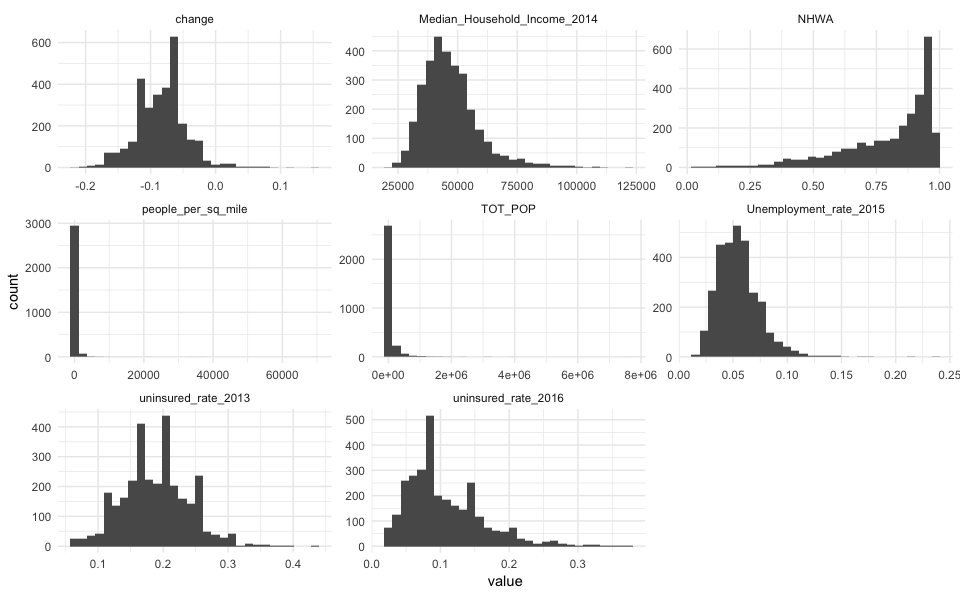

```r
joined_data %>%
  gather(key, value, people_per_sq_mile:NHWA) %>%
  ggplot(aes(x = value)) +
    geom_histogram() +
    facet_wrap(~key, scales = "free") +
    theme_minimal()
```

The “vote_difference” variable is of greatest interest here. The following correlations show us which variables are most related to the election outcomes per county.

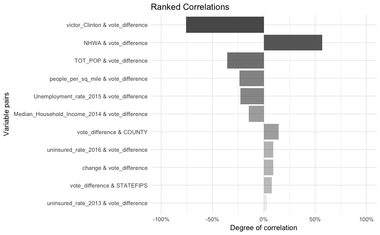

```r
library(forcats)
joined_data %>%
  rankedCorrelations() %>%
  filter(Vars1 == "vote_difference" | Vars2 == "vote_difference") %>%
  unite(Vars, Vars1, Vars2, sep = " & ") %>%
  arrange(abs(correlation)) %>%
  mutate(Vars = fct_inorder(Vars)) %>%
  ggplot(aes(x = Vars, y = correlation, alpha = log(abs(correlation)))) +
    geom_bar(stat = "identity") +
    coord_flip() +
    theme_minimal() +
    scale_y_continuous(labels = scales::percent, limits = c(-1,1)) +
    scale_alpha(guide = F) +
    labs(title = "Ranked Correlations",
         y = "Degree of correlation",
         x = "Variable pairs")
```

# Relationships

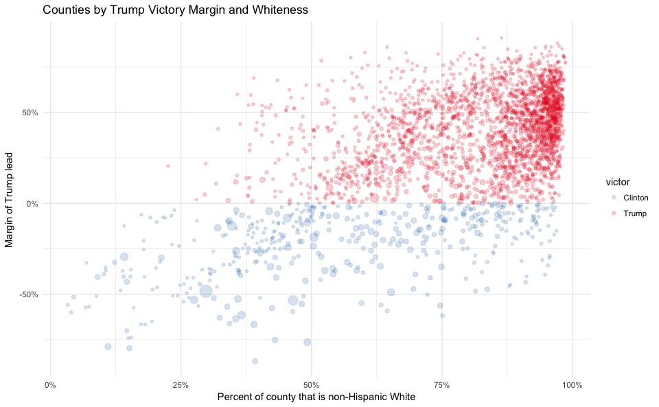

```r
joined_data %>%
  ggplot(aes(x = NHWA, y = vote_difference, size = TOT_POP, color = victor)) +
    geom_point(alpha = 1/5) +
    theme_minimal() +
    scale_color_brewer(type = "qual", palette = "Set1", direction = -1) +
    scale_x_continuous(labels = scales::percent) +
    scale_y_continuous(labels = scales::percent) +
    scale_size(guide = F) +
    labs(title = "Counties by Trump Victory Margin and Whiteness",
         x = "Percent of county that is non-Hispanic White",
         y = "Margin of Trump lead")
```

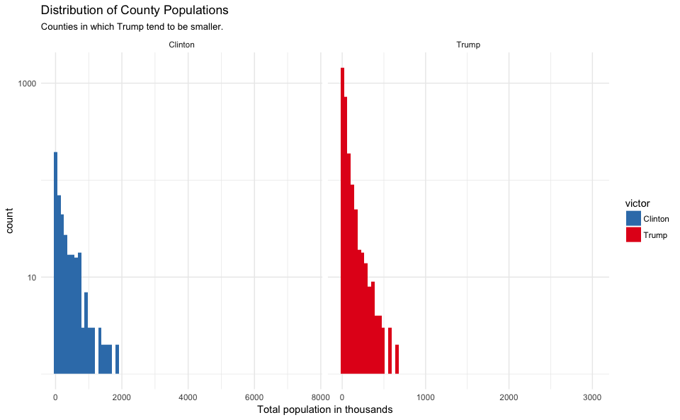

```r
joined_data %>%
  ggplot(aes(x = TOT_POP / 1000, fill = victor)) +
    geom_histogram(bins = 75) +
    facet_wrap(~victor, scales = "free_x") +
    theme_minimal() +
    scale_y_log10() +
    scale_fill_brewer(type = "qual", palette = "Set1", direction = -1) +
    labs(title = "Distribution of County Populations",
         subtitle = "Counties in which Trump tend to be smaller.",
         x = "Total population in thousands")
```

[figure not shown]

```r
joined_data %>%
  ggplot(aes(x = Unemployment_rate_2015, y = vote_difference, size = TOT_POP, color = victor)) +
    geom_point(alpha = 1/5) +
    facet_wrap(~cut(people_per_sq_mile,
                    breaks = c(-Inf, 15, 300, Inf),
                    labels= c("low density", "medium density", "high density")), scales = "free_x") +
    theme_minimal() +
    scale_color_brewer(type = "qual", palette = "Set1", direction = -1) +
    scale_x_continuous(labels = scales::percent) +
    scale_y_continuous(labels = scales::percent) +
    scale_size(guide = F) +
    labs(title = "Counties by Trump Victory Margin and Whiteness",
         subtitle = "Low density counties are more White and more pro Trump",
         x = "Percent of county that is non-Hispanic White",
         y = "Margin of Trump lead")
```

To detect multicolinearity, we show correlations between independent variables.

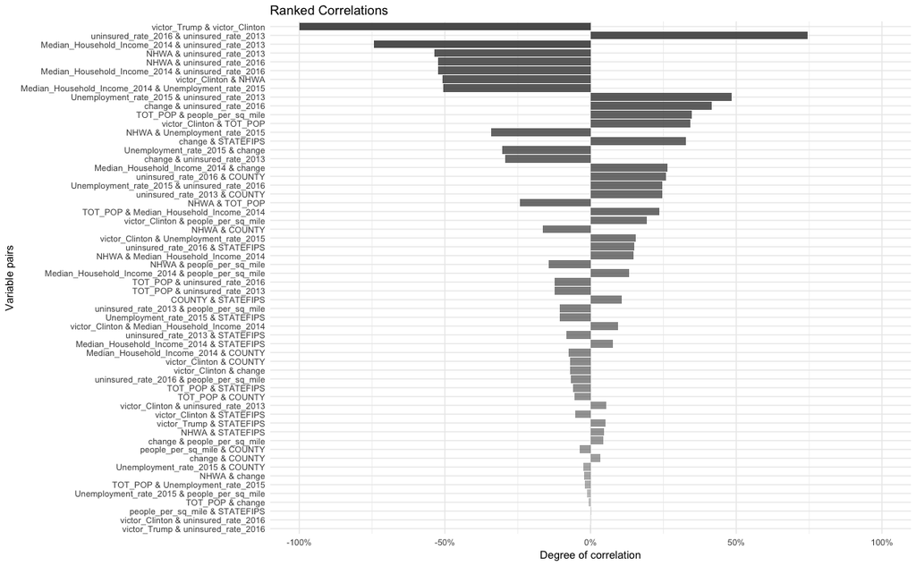

```r
joined_data %>%
  rankedCorrelations() %>%
  filter(Vars1 != "vote_difference" & Vars2 != "vote_difference") %>%
  unite(Vars, Vars1, Vars2, sep = " & ") %>%
  arrange(abs(correlation)) %>%
  mutate(Vars = fct_inorder(Vars)) %>%
  ggplot(aes(x = Vars, y = correlation, alpha = log(abs(correlation)))) +
    geom_bar(stat = "identity") +
    coord_flip() +
    theme_minimal() +
    scale_y_continuous(labels = scales::percent, limits = c(-1,1)) +
    scale_alpha(guide = F) +
    labs(title = "Ranked Correlations",
         y = "Degree of correlation",
         x = "Variable pairs")
```

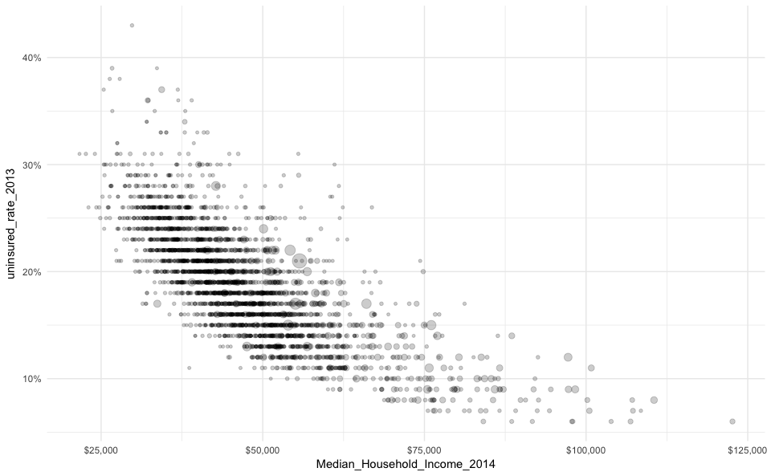

```r
joined_data %>%
  ggplot(aes(x = Median_Household_Income_2014, y = uninsured_rate_2013, size = TOT_POP)) +
    geom_point(alpha = 1/5) +
    theme_minimal() +
    scale_x_continuous(labels = scales::dollar) +
    scale_y_continuous(labels = scales::percent) +
    scale_size(guide = F)
```

# Random Forest Time

```r
library(randomForest)
sample_data <- (joined_data)
data.rf <- randomForest(x = select(joined_data, -vote_difference, -victor),
                        y = joined_data$vote_difference,
                        importance = T)
imp <- importance(data.rf, 1)[order(importance(data.rf, 1), decreasing = T),]
tibble(Variable = names(imp),`%Increase in MSE` = round(imp, 2) / 100)
```

| Variable | %Increase in MSE |
| --- | --- |
| NHWA | 0.9666 |
| STATEFIPS | 0.5780 |
| uninsured_rate_2016 | 0.5275 |
| TOT_POP | 0.4919 |
| Unemployment_rate_2015 | 0.4582 |
| uninsured_rate_2013 | 0.3786 |
| people_per_sq_mile | 0.3749 |
| Median_Household_Income_2014 | 0.3722 |
| change | 0.3215 |
| COUNTY | 0.2148 |